# **The Spotify Million Playlist Dataset Challenge**

Ryan Parker, Anthony Gu, Jason Yu

## Introduction

For our final [CMSC320 Introduction to Data Science](https://www.cs.umd.edu/class/spring2024/cmsc320-0201/) project, we are participating in the [Spotify Million Playlist Dataset Challenge](https://www.aicrowd.com/challenges/spotify-million-playlist-dataset-challenge).

The Million Playlist Dataset (MPD) contains 1,000,000 playlists created by users on the Spotify platform. These playlists were created during the period of January 2010 through October 2017. Each playlist in the MPD contains a playlist title, the track list (including track metadata) editing information (last edit time, number of playlist edits) and other miscellaneous information about the playlist.

The Spotify MPD Challenge is a continuation of the RecSys Challenge 2018, which ran from January to July 2018. The evaluation task is automatic playlist continuation: given a seed playlist title and/or initial set of tracks in a playlist, to predict the subsequent tracks in that playlist.

This is an open-ended challenge intended to encourage research in music recommendations. The Digital Music Alliance, in their 2018 Annual Music Report, state that 54% of consumers say that playlists are replacing albums in their listening habits. And according to Spotify,

> ...users don’t love just listening to playlists, they also love creating them. To date, over 4 billion playlists have been created and shared by users. People create playlists for all sorts of reasons: some playlists group together music categorically (e.g., by genre, artist, year, or city), by mood, theme, or occasion (e.g., romantic, sad, holiday), or for a particular purpose (e.g., focus, workout). Some playlists are even made to land a dream job, or to send a message to someone special.

> By learning from the playlists that people create, we can learn all sorts of things about the deep relationship between people and music. Why do certain songs go together? What is the difference between “Beach Vibes” and “Forest Vibes”? And what words do people use to describe which playlists?

> By learning more about nature of playlists, we may also be able to suggest other tracks that a listener would enjoy in the context of a given playlist. This can make playlist creation easier, and ultimately help people find more of the music they love.

## Final Tutorial

The data science lifecycle we will be going through will include the following:

1. Data Collection
2. Data Processing
3. Data Analysis and Visualization
4. Applying Machine Learning
5. Our Interpretation and Insight

# Data Collection

Our first stop in the data science life cycle, we need to find the data that we would like to use. After conducting some extensive research, our team decided to work with Spotify song data. Our main inspiration behind this decision was a challenge called the Spotify Million Playlist Dataset Challenge in 2018 to create an algorithm for Spotify that picks recommended songs to add to a playlist, which had a dataset of a million playlists. It was released on AI crowd back in 2020, which means we should have good access to a database to use. This data set is also quite recent.

Our tutorial is based off the data and inspired by the task of this challenge, but it does not directly follow the specific guidelines or requirements of the actual contest. If you would like to explore this other resource more on your own, feel free to check out the challenge page linked here: https://www.aicrowd.com/challenges/spotify-million-playlist-dataset-challenge

So, to start our actual data collection stage, we first download the data from the AIcrowd, then loading up a file to see what each JSON looks like. The important things tags seem to be the "playlists" from the main JSON, as well as "tracks". From here, we try to figure out how to iterate through playlists, as well as how to iterate through songs in the playlist.

For more information regarding the JSON format and reading JSON files in python, feel free to read more here: to https://www.geeksforgeeks.org/read-json-file-using-python/

Also, throughout this project we will be using the Python programming language and use tools like Jupyter Notebook to develop this project.

```python
# Putting required imports here to reduce issues later. May want to move to its respective sections
import os
import json
import numpy as np
```

```python
# Use a Raw String (r'') so backslashes aren't interpreted as escape characters
path_to_data = r'D:\320 Final Data\data'
```

```python
# Opening JSON file - Note this is only 1, will use more later
with open(os.path.join(path_to_data, 'mpd.slice.0-999.json')) as f:
    data = json.load(f)

# Getting the playlist data from the JSON object
playlists = data.get('playlists', {})
```

## Data Processing

At this stage in the data science life cycle, we now want to process our data and extract only the necessary components to be used later. In the provided data from Spotify, we can find numerous variables such as artist name, track name, different URIs, and more. For our tutorial, we will just be using the track name to form our song recommendations. Our team decided to only use the track name because other variables, such as the URI variables, were only really relevant to Spotify, and not needed for actual analysis.

```python
# Iterate through 5 playlists, printing out the first track data to shorted output
x = 0
for item in playlists:
   if x >= 5:
      break
   x += 1
   print(item.get("tracks")[0])
```

```
{'pos': 0, 'artist_name': 'Missy Elliott', 'track_uri': 'spotify:track:0UaMYEvWZi0ZqiDOoHU3YI', 'artist_uri': 'spotify:artist:2wIVse2owClT7go1WT98tk', 'track_name': 'Lose Control (feat. Ciara & Fat Man Scoop)', 'album_uri': 'spotify:album:6vV5UrXcfyQD1wu4Qo2I9K', 'duration_ms': 226863, 'album_name':…
{'pos': 0, 'artist_name': 'Survivor', 'track_uri': 'spotify:track:2HHtWyy5CgaQbC7XSoOb0e', 'artist_uri': 'spotify:artist:26bcq2nyj5GB7uRr558iQg', 'track_name': 'Eye of the Tiger', 'album_uri': 'spotify:album:4PT9VulQaQP6XR1xBI2x1W', 'duration_ms': 243773, 'album_name': 'Eye Of The Tiger'}
{'pos': 0, 'artist_name': 'Hoody', 'track_uri': 'spotify:track:74tqql9zP6JjF5hjkHHUXp', 'artist_uri': 'spotify:artist:7lXgbtBDcCRbfc5f8FhGUL', 'track_name': 'Like You', 'album_uri': 'spotify:album:7hq1c0ZrLiSKxzhoRacoG7', 'duration_ms': 212715, 'album_name': 'On And On'}
{'pos': 0, 'artist_name': 'Camille Saint-Saëns', 'track_uri': 'spotify:track:4WJ7UMD4i6DOPzyXU5pZSz', 'artist_uri': 'spotify:artist:436sYg6CZhNefQJogaXeK0', 'track_name': 'Danse macabre', 'album_uri': 'spotify:album:0T9YCy8TruLD6Z4qiCGSn6', 'duration_ms': 428560, 'album_name': 'French Festival'}
{'pos': 0, 'artist_name': 'The Smashing Pumpkins', 'track_uri': 'spotify:track:4iCGSi1RonREsPtfEKYj5b', 'artist_uri': 'spotify:artist:40Yq4vzPs9VNUrIBG5Jr2i', 'track_name': 'Tonight, Tonight', 'album_uri': 'spotify:album:4bPT6Q8ppaSNppk1kbEbLl', 'duration_ms': 254626, 'album_name': 'Mellon Collie an…
```

```python
# Iterate through 5 songs in a playlist
x = 0
for song in playlists[0].get("tracks"):
    if x >= 5:
        break
    x += 1
    print(song.get("track_name"))
```

```
Lose Control (feat. Ciara & Fat Man Scoop)
Toxic
Crazy In Love
Rock Your Body
It Wasn't Me
```

Now, we've created a way to view the songs in playlists. This is a very useful breakthrough in our data processing. With cleaner, more processed data, we are able to do so much more in our later steps with analysis, visualization, and applying machine learning techniques.

We also will now create a test set to use utilizing the last dataset. We will use this test set later in the tutorial to apply certain machine learning techniques.

```python
def makeTestSet():
    # Same process as earlier
    f = open(path_to_data + '\\mpd.slice.999000-999999.json')
    data = json.load(f)
    f.close()

    # Getting the playlist data from the JSON object
    testplaylists = data.get('playlists', {})

    testList = []
    x = 0

    for playlist in testplaylists:
        curSong = 0
        total = int(playlist.get("num_tracks"))
        testList.append([set(),set()])
        for song in playlist.get("tracks"):
            if curSong < total // 2:
                testList[x][0].add(song.get("track_name"))
            else:
                testList[x][1].add(song.get("track_name"))
            curSong += 1
        x += 1
    return testList
testSet = makeTestSet()
```

# Exploratory Data Analysis and Visualization

In this part of the data analysis life cycle, we are going to start a deeper analysis of the data through plots. Plots, or in other words, graphing the data, will help us visualize the trends easier. In addition, from this part of data analysis we can gain actual evidence for our later insights on trends.

Now that we have all the data we want and need from the data collection and processing parts, we should start by looking for potential trends. One thing that would be good to start on would be the frequency of each song. We can do this simply by iterating through every song and incrementing a dictionary that uses the song title as the key.

```python
songs = {}
iters = 100 # Iterate through iters * 1000 playlists, About 1min per 100
#iters = 1
x = 0
# Iterate through files in the folder
for filename in os.listdir(path_to_data):
    if x >= iters:
        break
    x += 1
    file_path = os.path.join(path_to_data, filename)

    f = open(file_path)
    data = json.load(f)
    f.close()
    playlists = data.get('playlists', {})

    for playlist in playlists:
        for song in playlist.get("tracks"):
            val = song.get("track_name")
            if val not in songs:
                songs[val] = 1
            else:
                songs[val] += 1

for x in range(5):
    print(list(songs.keys())[x])
```

```
Lose Control (feat. Ciara & Fat Man Scoop)
Toxic
Crazy In Love
Rock Your Body
It Wasn't Me
```

However at a glance, our team noticed that just having the song names wasn't particularly useful though, and with so many songs it makes more sense to only look at the most common ones. So with this in mind, we tried to retrieve more useful data and important metrics to go with it.

```python
# Sorting the data by amount of appearances, in reverse order
songs = sorted(songs.items(), key=lambda item: item[1], reverse=True)

for x in range(5):
    print(songs[x])
```

```
('Closer', 6683)
('Home', 5049)
('HUMBLE.', 4578)
('One Dance', 4440)
('Roses', 4414)
```

Now that we have the data sorted by amount of appearances and the most popular songs from the data set, lets make a graph of the 20 most added songs based on that data. By graphing the data, we will be able to visualize the popularity of songs.

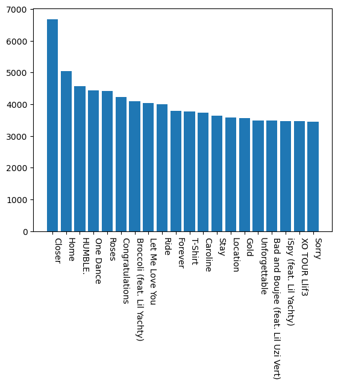

```python
# Visualizing the data
import matplotlib.pyplot as plt

# Converting it back to a dictionary
frequencySongs = {}
for (key, val) in songs:
    frequencySongs[key] = val

# Creating a bar graph of the 20 most popular songs
plt.bar(list(frequencySongs.keys())[:20], list(frequencySongs.values())[:20])

# Making them up and donw to
plt.xticks(rotation=-90, ha = 'left')

plt.show()
```

```python
print(testSet[0])
print(len(testSet[1][0]))
print(len(testSet))
```

```
[{'Time To Say Goodbye (Con Te Partiro)', 'Serenade für Streicher Nr. 13, G-Dur, KV 525: I. Allegro', 'River Flows In You', 'Ballade No. 4 in F minor Op. 52', "Give 'Em a Chance", 'Landing Peleliu', "L'Estasi Dell'oro (The Ecstasy Of Gold) - 2004 Digital Remaster", 'The Four Seasons', 'Honor [Main T…
7
1000
```

And with that, we have what we need for our first recommendation system. All we have to do is find the first x many songs that aren't already in the playlist and suggest them, based on the numebr of appearances in all playlists from the Spotify data we collected and processed earlier.

```python
def frequencyRecommendation(playlist, amt = 100):
    songs = []
    x = 0
    freqSongs = list(frequencySongs.keys())
    while len(songs) < amt:
        if freqSongs[x] not in playlist:
            songs.append(freqSongs[x])
        x += 1
    return songs

freqRecommends = frequencyRecommendation(testSet[0][0])
for x in range(10):
    print(freqRecommends[x])
```

```
Closer
Home
HUMBLE.
One Dance
Roses
Congratulations
Broccoli (feat. Lil Yachty)
Let Me Love You
Ride
Forever
```

There we go. We now have recommended songs based on the Spotify data. Seems simple, maybe too good to be true. For that reason, lets create a loss function to see how well it works, by checking how many this technique can predict.

```python
# Loss function, closer to 0 is better - May want to change later
def loss(playlist, recommendations):
    temp = set(playlist.copy())
    for song in recommendations:
        if song in temp:
            temp.remove(song)
    return len(temp)/len(playlist)
```

```python
def totalLoss(playlists, func):
    total = 0
    for playlist in playlists:
        total += loss(playlist[1], func(playlist[0]))
    return total/len(playlists)
totalLoss(testSet, frequencyRecommendation) # Around 20 seconds, .957
```

```
0.9572431744296627
```

As you can see, our current method isn't particularly good. It only guesses the most popular songs, meaning that it ignores the rest of the dataset. We aren't using our resources effectively now. In fact, after 100 recommendations, our technique on average gets only 4% of the remaining songs in the playlist.

So now we must retry, and think of a new approach to recommending songs. One idea is that we can also see which songs are commonly put in the same playlist as each other. This would be done by iterating through the songs twice and using a 2D dictionary to increment whenever two songs are in the same playlist as each other. This would give us a matrix that shows common songs, which we could then use to find the songs that are most likely to be in a new playlist.

However we may run into some potential Issues:

- May ignore songs that are almost always together (Fix by increasing the increment value in smaller playlists)
- May disregard less popular songs (TBD how to fix)
- BIG matrix
- Could be quite slow

```python
# Analysis pt. 2
# 16 seconds for 1000 playlists, how to speed up?, 11 min for 100,000 (Seems qiocker now)
# May want to convert to list

# The following code generates a dictionary matrix which is stored in a file called "SharedMatrix.txt". This may take a long time, so it reduces the time required
def genPairedSongs():
    songs2 = {}
    iters = 100 # Iterate through iters * 1000 playlists, around 15 seconds per iter
    #iters = 1 # Uncomment for small test runs
    x = 0
    # Iterate through files in the folder
    for filename in os.listdir(path_to_data):
        if x >= iters:
            break
        x += 1
        file_path = os.path.join(path_to_data, filename)

        f = open(file_path)
        data = json.load(f)
        f.close()
        playlists = data.get('playlists', {})

        for playlist in playlists:
            for song in playlist.get("tracks"):
                val = song.get("track_name")
                if val not in songs2:
                    songs2[val] = {}
                for song2 in playlist.get("tracks"):
                    val2 = song2.get("track_name")
                    if val2 not in songs2[val]:
                        songs2[val][val2] = 1
                    else:
                        songs2[val][val2] += 1


    # Removing very small tracks
    newsongs2 = {}
    for song in songs2:
        newsongs2[song] = {}
        for song2 in songs2[song]:
            if songs2[song][song2] > 10:
                newsongs2[song][song2] = songs2[song][song2]
        if len(songs2[song]) == 0:
            newsongs2.pop(song)

    # Saving the above in a text document to save time
    with open("SharedMatrix.txt", 'w') as f:
        json.dump(newsongs2, f)

#genPairedSongs() # Uncomment to create a new SharedMatrix.txt, around 11 mins
```

```python
# Far quicker option, load a JSON from SharedMatrix.txt as opposed to creating one every time
def loadPairedSongs():
    with open("SharedMatrix.txt", 'r') as f:
        return json.load(f)

pairedSongs = loadPairedSongs()
```

```python
# Takes a long time, look into fixing
def pairedRecommendations(playlist, amt = 100):
    playlist = set(playlist)
    scores = {}
    songs = []
    for song in playlist:
        if song in pairedSongs:
            for (name, score) in pairedSongs[song].items():
                if name not in scores:
                    scores[name] = score
                else:
                    scores[name] += score
    scores = sorted(scores.items(), key=lambda item: item[1], reverse=True)
    x = 0
    while len(songs) < amt and x < len(scores):
        if scores[x][0] not in playlist:
            songs.append(scores[x][0])
        x += 1
    return songs

pairedRecommends = pairedRecommendations(testSet[0][0])
for x in range(10):
    print(pairedRecommends[x])
```

```
Skinny Love
Kiss The Rain
Hallelujah
Say Something
Chasing Cars
All of Me
A Thousand Years
Time
Breathe Me
Comptine d'un autre été, l'après-midi
```

Using the loss function for paired recommendations algorithm, we get the following loss. This is an improvement from our last technique, but how can we further improve our findings? Machine Learning.

```python
totalLoss(testSet, pairedRecommendations)
```

```
0.8304100637044947
```

Additionally, if you would like to download the SharedMatrix.txt file used in the code above, it can be found here: https://www.dropbox.com/scl/fi/0f3h42i2yvtbelm8biwr0/SharedMatrix.txt?rlkey=20ljgdkfvvdr1vw3u2sey2p3b&e=1&st=hep1eabb&dl=0

# Applying Machine Learning

Code:

```
from sklearn.cluster import KMeans

X = df

kmeans = KMeans(
    n_clusters=5,
    random_state=0,
    n_init="auto"
).fit(X)

for i in kmeans.labels_:
    print(i, end=' ')
```

Output:

```
4 4 4 4 4 4 4 4 4 4 4 4 4 4 4 4 4 4 4 4 4 4 4 4 4 4 4 4 4 4 4 4 4 4 4 4 4 4 4 4 4 4 4 4 4 4 4 4 4 4 4 4 4 3 4 4 4 4 4 4 4 4 4 4 4 4 4 4 4 4 4 4 4 4 4 4 4 4 4 4 4 4 4 4 4 4 4 4 4 4 4 4 4 4 4 3 4 4 4 4 4 4 4 4 4 4 4 4 4 4 4 4 4 4 4 4 4 4 4 4 4 4 4 3 3 4 4 4 4 4 4 4 4 4 4 4 4 4 4 4 4 4 4 4 4 4 4 4 4 4 4 4 4 4 4 4 4 4 4 4 4 3 4 4 4 4 4 4 4 4 4 4 4 4 4 4 4 4 3 4 4 4 3 4 4 4 4 4 4 4 4 4 4 4 4 4 4 4 4 4 4 4 4 4 4 4 4 4 4 4 4 4 4 4 3 4 4 4 4 4 4 4 4 4 4 4 4 4 4 4 4 4 4 4 4 4 4 4 4 3 4 4 4 4 4 4 4 4 4 4 4 4 4 3 4 4 4 4 4 4 4 4 4 4 4 4 4 4 4 4 4 4 4 4 4 4 4 4 4 4 4 4 4 4 4 3 4 4 4 4 4 4 4 4 3 4 4 4 4 4 4 4 4 4 4 4 4 4 4 4 4 4 4 4 4 4 4 4 4 4 4 4 4 4 4 4 4 4 4 4 4 4 4 4 4 3 4 4 4 4 4 4 4 4 4 4 4 4 4 4 4 4 4 4 4 4 4 4 4 4 3 4 4 4 4 4 4 4 4 4 4 4 4 4 4 4 4 4 4 4 4 4 4 4 4 4 4 4 4 3 4 4 4 4 4 4 4 4 4 4 4 4 4 3 4 4 4 4 4 4 4 3 4 4 4 4 4 4 4 4 4 4 4 4 4 4 4 4 4 4 4 4 4 4 4 4 2 4 4 4 4 4 4 4 4 4 4 4 4 4 4 4 3 4 3 4 4 4 4 4 4 4 4 4 4 4 4 4 4 4 4 3 4 4 4 4 4 4 4 4 4 4 4 4 4 4 4 4 4 4 4 4 4 4 4 4 4 4 4 4 4 4 4 4 4 4 4 4 4 4 4 4 4 4 4 4 4 4 4 4 4 4 4 4 4 4 3 4 3 4 4 4 4 4 4 4 4 4 4 4 4 4 4 4 4 4 3 4 0 4 4 4 4 4 1 4 4 4 4 3 3 4 4 4 4 4 4 4 4 4 4 4 3 4 4 4 4 4 4 4 4 4 4 4 4 4 4 4 4 4 4 4 4 4 4 4 4 4 4 4 3 4 4 4 4 3 4 4 4 4 4 4 3 4 4 4 4 4 4 4 4 4 4 4 4 4 4 4 4 4 4 4 4 3 4 4 4 4 4 4 4 4 3 4 4 4 4 4 4 4 4 4 4 4 4 4 4 4 4 4 4 4 4 4 4 4 4 4 4 4 4 4 4 4 4 4 4 4 4 4 4 4 4 3 4 4 4 4 4 4 4 4 4 4 4 4 4 4 4 4 4 4 4 4 3 4 4 4 4 4 4 4 4 4 4 4 4 4 4 4 4 4 4 4 4 4 4 4 4 4 4 4 4 4 4 4 4 4 4 4 4 4 4 3 4 4 4 4 4 4 4 4 4 4 4 4 4 4 4 4 4 4 4 4 4 4 3 3 4 4 4 4 4 4 4 4 4 4 4 4 4 4 3 4 4 4 4 4 4 4 4 4 4 4 4 4 4 4 4 4 4 4 4 4 4 4 4 4 4 4 4 4 4 4 4 4 4 4 4 4 4 4 3 4 4 4 4 4 4 4 4 4 4 4 4 3 4 4 4 4 3 4 4 3 4 4 4 4 4 4 4 4 4 4 4 4 4 4 4 4 4 4 4 4 4 4 4 4 4 4 4 4 4 4 4 4 4 4 4 4 4 4 4 4 4 4 3 4 4 4 4 4 4 4 4 4 4 4 4 4 4 4 4 4 4 4 4 3 4 4 4 4 4 3 4 4 4 4 4 4 4 4 4 4 4 4 4 4 4 4 4 4 4 4 4 4 4 4 4 4 3 3 4 4 4 4 4 4 4 4 4 4 4 4 4 4 4 4 4 4 4 4 4 4 3 3 4 4 4 4 4 3 4 4 4 4 4 3 4 4 3 4 4 4 3 4 4 4 4 4 4 4 4 4 4 4 4 4 4 4
```

Unfortunately, the algorithm seemed to group nearly every playlist under the same cluster. In fact, clusters 0 and 1 each only contain one playlist. Our hypothesis for why this was happening was because many playlists *don't* share a significant amount of songs, placing them closer together.

# Apriori Algorithm and Association Rule Learning/Mining

This is not an algorithm that we learned about in class, but it is a type of unsupervised learning, which we did learn about. Association Rule Learning is commonly used with Market Basket Analysis, which is where products are recommended to customers based on what they already have. For example, Amazon will recommend you additional items you may be interested in based on items in your cart.

We realized that this was very similar to Spotify playlists. Using the Apriori algorithm which implements Association Rule learning, we would be able to solve our problem.

## Load JSON data

Because of the significant size of the dataset (31GB), we're going to start with the first 1000 playlists.

```python
with open(os.path.join(path_to_data, 'mpd.slice.0-999.json')) as f:
    data = json.load(f)
```

The first 36 lines are shown below:

```
{
    "info": {
        "generated_on": "2017-12-03 08:41:42.057563",
        "slice": "0-999",
        "version": "v1"
    },
    "playlists": [
        {
            "name": "Throwbacks",
            "collaborative": "false",
            "pid": 0,
            "modified_at": 1493424000,
            "num_tracks": 52,
            "num_albums": 47,
            "num_followers": 1,
            "tracks": [
                {
                    "pos": 0,
                    "artist_name": "Missy Elliott",
                    "track_uri": "spotify:track:0UaMYEvWZi0ZqiDOoHU3YI",
                    "artist_uri": "spotify:artist:2wIVse2owClT7go1WT98tk",
                    "track_name": "Lose Control (feat. Ciara & Fat Man Scoop)",
                    "album_uri": "spotify:album:6vV5UrXcfyQD1wu4Qo2I9K",
                    "duration_ms": 226863,
                    "album_name": "The Cookbook"
                },
                {
                    "pos": 1,
                    "artist_name": "Britney Spears",
                    "track_uri": "spotify:track:6I9VzXrHxO9rA9A5euc8Ak",
                    "artist_uri": "spotify:artist:26dSoYclwsYLMAKD3tpOr4",
                    "track_name": "Toxic",
                    "album_uri": "spotify:album:0z7pVBGOD7HCIB7S8eLkLI",
                    "duration_ms": 198800,
                    "album_name": "In The Zone"
                },
...
```

## Metrics

Before we perform any data analysis, we will require various metrics:

```python
num_playlists = len(data['playlists'])
num_playlists
```

```
1000
```

```python
num_tracks = 0

for p in data['playlists']:
    for t in p['tracks']:
        num_tracks += 1

num_tracks
```

```
67503
```

```python
unique_tracks = set() # Use a set to prevent duplicates

for p in data['playlists']:
    for t in p['tracks']:
        unique_tracks.add(t['track_uri'])

num_unique_tracks = len(unique_tracks)
num_unique_tracks
```

```
34443
```

## Handle Duplicates

We then realized that Spotify sometimes has multiple listings for the same song, for example sometimes in different albums. So, the number of unique tracks doesn't actually reflect the number of unique songs. To address, this, we will need a more complicated system where we keep track of songs not only by their `track_uri` but also by their artist.

```python
class Song:
    def __init__(self, track_uri, track_name, artist_uri, artist_name):
        self.track_uri = track_uri
        self.track_name = track_name
        self.artist_uri = artist_uri
        self.artist_name = artist_name

    def __eq__(self, other):
        return (self.track_name == other.track_name) and (self.artist_uri == other.artist_uri)

    def __hash__(self):
        return hash((self.track_name, self.artist_uri))

    def __repr__(self):
        return f'{self.track_name}—{self.artist_name}'
```

```python
unique_songs = set()

for p in data['playlists']:
    for t in p['tracks']:
        song = Song(t['track_uri'], t['track_name'], t['artist_uri'], t['artist_name'])
        unique_songs.add(song)

num_unique_songs = len(unique_songs)
num_unique_songs
```

```
34250
```

## Convert JSON to Pandas DataFrame

To run the Apriori Algorithm, we will first need a one-hot encoded table, with the "baskets" as rows and the "items" as columns.

```python
import pandas as pd
```

```python
presence_dict = {song: [False] * num_playlists for song in unique_songs}

for i,p in enumerate(data['playlists']):
    for t in p['tracks']:
        song = Song(t['track_uri'], t['track_name'], t['artist_uri'], t['artist_name'])
        presence_dict[song][i] = True

df = pd.DataFrame(presence_dict)
df
```

|  | Bang And Blame—R.E.M. | G Train—Thirdstory | Knockout—Lil Wayne | Great Divide—The Cardigans | Why Won't You Make Up Your Mind?—Tame Impala | Gold Canary—Cloud Control | Sedona—Houndmouth | Under the Sun—DIIV | Again I Say Rejoice—Israel Houghton | Home Bittersweet Home—The Color Morale | ... | Whispered Words (Pretty Lies)—Dan Auerbach | Our Glass—Shotta Spence | Party Ain't A Party—Jamie Foxx | Columbus—Snowmine | Rosana—Wax | Of the Girl - Instrumental 2000—Pearl Jam | Switch Up—Big Sean | H.S.K.T.—Sylvan Esso | Acércate (feat. Nicky Jam) - Remix—De La Ghetto | Praise Him In Advance—Marvin Sapp |
| --- | --- | --- | --- | --- | --- | --- | --- | --- | --- | --- | --- | --- | --- | --- | --- | --- | --- | --- | --- | --- | --- |
| 0 | False | False | False | False | False | False | False | False | False | False | ... | False | False | False | False | False | False | False | False | False | False |
| 1 | False | False | False | False | False | False | False | False | False | False | ... | False | False | False | False | False | False | False | False | False | False |
| 2 | False | False | False | False | False | False | False | False | False | False | ... | False | False | False | False | False | False | False | False | False | False |
| 3 | False | False | False | False | False | False | False | False | False | False | ... | False | False | False | False | False | False | False | False | False | False |
| 4 | False | False | False | False | False | False | False | False | False | False | ... | False | False | False | False | False | False | False | False | False | False |
| ... | ... | ... | ... | ... | ... | ... | ... | ... | ... | ... | ... | ... | ... | ... | ... | ... | ... | ... | ... | ... | ... |
| 995 | False | False | False | False | False | False | False | False | False | False | ... | False | False | False | False | False | False | False | False | False | False |
| 996 | False | False | False | False | False | False | False | False | False | False | ... | False | False | False | False | False | False | False | False | False | False |
| 997 | False | False | False | False | False | False | False | False | False | False | ... | False | False | False | False | False | False | False | False | False | False |
| 998 | False | False | False | False | False | False | False | False | False | False | ... | False | False | False | False | False | False | False | False | False | False |
| 999 | False | False | False | False | False | False | False | False | False | False | ... | False | False | False | False | False | False | False | False | False | False |

1000 rows × 34250 columns

### Some Exploratory Data Analysis

```python
df.values.sum()
```

```
66666
```

```python
num_tracks - df.values.sum()
```

```
837
```

A small fraction of were not accounted for. This can be explained by tracks that appear multiple times in a single playlist. Their effect is minimal, so we will ignore these cases.

## Run Apriori

We'll use the Mlxtend (machine learning extensions) library

```python
from mlxtend.frequent_patterns import apriori, association_rules
```

### Choosing min_support

The `min_support` parameter controls minimum support required for an itemset to be selected. We started with a value of `0.5` but decreased it to `0.01` since we found that `0.5` didn't create enough "baskets".

```python
freq_items = apriori(df, min_support=0.01, low_memory=True, use_colnames=True)
freq_items
```

|  | support | itemsets |
| --- | --- | --- |
| 0 | 0.013 | (Sober—Childish Gambino) |
| 1 | 0.020 | (One Night—Lil Yachty) |
| 2 | 0.016 | (Fortunate Son—Creedence Clearwater Revival) |
| 3 | 0.020 | (Drunk in Love—Beyoncé) |
| 4 | 0.010 | (Birthday Sex—Jeremih) |
| ... | ... | ... |
| 1943 | 0.010 | (Mask Off—Future, goosebumps—Travis Scott, Con... |
| 1944 | 0.010 | (iSpy (feat. Lil Yachty)—KYLE, Congratulations... |
| 1945 | 0.010 | (iSpy (feat. Lil Yachty)—KYLE, No Problem (fea... |
| 1946 | 0.010 | (iSpy (feat. Lil Yachty)—KYLE, goosebumps—Trav... |
| 1947 | 0.010 | (iSpy (feat. Lil Yachty)—KYLE, Chill Bill—Rob ... |

1948 rows × 2 columns

## Generate the Association Rules

```python
rules = association_rules(freq_items, metric='confidence', min_threshold=0.6)
```

## Examine the rules with the most confidence and lift

```python
rules = rules.sort_values(['confidence', 'lift'], ascending =[False, False])
rules.head(10)
```

|  | antecedents | consequents | antecedent support | consequent support | support | confidence | lift | leverage | conviction | zhangs_metric |
| --- | --- | --- | --- | --- | --- | --- | --- | --- | --- | --- |
| 138 | (Bad and Boujee (feat. Lil Uzi Vert)—Migos, X ... | (No Heart—21 Savage) | 0.012 | 0.020 | 0.012 | 1.0 | 50.000000 | 0.011760 | inf | 0.991903 |
| 1891 | (Bad and Boujee (feat. Lil Uzi Vert)—Migos, Ch... | (iSpy (feat. Lil Yachty)—KYLE, Bounce Back—Big... | 0.010 | 0.021 | 0.010 | 1.0 | 47.619048 | 0.009790 | inf | 0.988889 |
| 1717 | (iSpy (feat. Lil Yachty)—KYLE, Chill Bill—Rob ... | (Bounce Back—Big Sean, Congratulations—Post Ma... | 0.011 | 0.023 | 0.011 | 1.0 | 43.478261 | 0.010747 | inf | 0.987867 |
| 1884 | (iSpy (feat. Lil Yachty)—KYLE, Chill Bill—Rob ... | (Bounce Back—Big Sean, Congratulations—Post Ma... | 0.010 | 0.023 | 0.010 | 1.0 | 43.478261 | 0.009770 | inf | 0.986869 |
| 1344 | (Mask Off—Future, Chill Bill—Rob $tone) | (XO TOUR Llif3—Lil Uzi Vert, Congratulations—P... | 0.011 | 0.024 | 0.011 | 1.0 | 41.666667 | 0.010736 | inf | 0.986855 |
| 1703 | (iSpy (feat. Lil Yachty)—KYLE, Mask Off—Future... | (XO TOUR Llif3—Lil Uzi Vert, Congratulations—P... | 0.010 | 0.024 | 0.010 | 1.0 | 41.666667 | 0.009760 | inf | 0.985859 |
| 364 | (No Heart—21 Savage, Caroline—Aminé) | (X (feat. Future)—21 Savage) | 0.010 | 0.026 | 0.010 | 1.0 | 38.461538 | 0.009740 | inf | 0.983838 |
| 1849 | (iSpy (feat. Lil Yachty)—KYLE, No Problem (fea... | (HUMBLE.—Kendrick Lamar, Congratulations—Post ... | 0.010 | 0.026 | 0.010 | 1.0 | 38.461538 | 0.009740 | inf | 0.983838 |
| 1877 | (iSpy (feat. Lil Yachty)—KYLE, Congratulations... | (Chill Bill—Rob $tone) | 0.010 | 0.028 | 0.010 | 1.0 | 35.714286 | 0.009720 | inf | 0.981818 |
| 707 | (Trap Queen—Fetty Wap, Jumpman—Drake) | (Panda—Desiigner) | 0.010 | 0.035 | 0.010 | 1.0 | 28.571429 | 0.009650 | inf | 0.974747 |

# Visualize Results

```python
import matplotlib.pyplot as plt
```

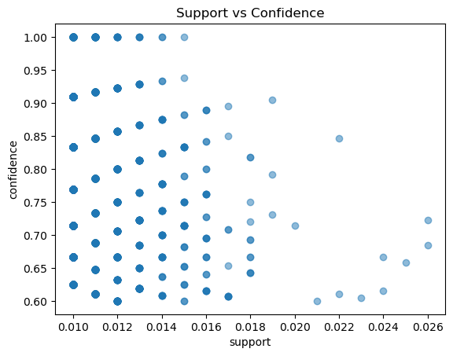

```python
plt.scatter(rules['support'], rules['confidence'], alpha=0.5)
plt.xlabel('support')
plt.ylabel('confidence')
plt.title('Support vs Confidence')
plt.show()
```

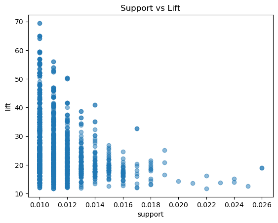

```python
plt.scatter(rules['support'], rules['lift'], alpha=0.5)
plt.xlabel('support')
plt.ylabel('lift')
plt.title('Support vs Lift')
plt.show()
```

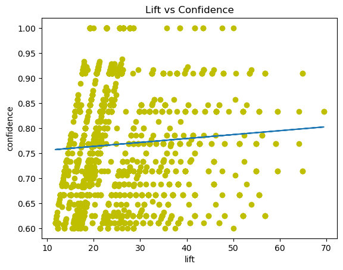

```python
fit = np.polyfit(rules['lift'], rules['confidence'], 1)
fit_fn = np.poly1d(fit)
plt.plot(rules['lift'], rules['confidence'], 'yo', rules['lift'],
fit_fn(rules['lift']))
plt.xlabel('lift')
plt.ylabel('confidence')
plt.title('Lift vs Confidence')
plt.show()
```

# Predict

We will use the next JSON file, 'mpd.slice.1000-1999.json', to make predictions.

```python
with open(os.path.join(path_to_data, 'mpd.slice.1000-1999.json')) as f:
    validation_data = json.load(f)
```

To evaluate predictions, we will remove half the songs from each playlist, then see how many of the removed songs are recommended based on the other half songs.

```python
scores = []

for p in validation_data['playlists']:

    playlist = set() # Ignore duplicates
    antecedents = set()
    consequents = set()
    removed = set()

    # Get all the tracks in the playlist
    for t in p['tracks']:
        song = Song(t['track_uri'], t['track_name'], t['artist_uri'], t['artist_name'])
        playlist.add(song)

    # Remove half of the tracks
    for i in range(len(playlist)//2):
        if len(playlist) > 0:
            removed.add(playlist.pop())

    # Check which rules apply to the playlist
    for i,r in rules.iterrows():
        if r['antecedents'].issubset(playlist):
            antecedents = antecedents.union(r['antecedents'])
            consequents = consequents.union(r['consequents'])
        if len(consequents.difference(playlist)) >= len(playlist)//2:
            break

    # Discard songs already in the playlist
    consequents = consequents.difference(playlist)

    if len(antecedents) > 0 and len(consequents) > 0:

        correct = consequents.intersection(removed)
        incorrect = consequents - correct

        score = len(correct)/(len(correct)+len(incorrect))
        scores += [score]

        # debug function. Print the first 10 items of a set
        def print_set(a, n=-1):
            for i,s in enumerate(a):
                if i == n:
                    break
                print(f'    {s}')
        # DEBUG
#         print(f'Since your playlist ({len(playlist)} songs) includes:')
#         print_set(antecedents)
#         print('We think you\'ll also like:')
#         print_set(consequents)
#         print('Correctly recommended:')
#         print_set(correct)
#         print('Incorrectly recommended')
#         print_set(incorrect)
#         print('Score:')
#         print(f'    {score}')
#         print()
#         print()

print(np.mean(scores))
print(np.median(scores))
print(np.std(scores))
print(np.var(scores))
```

```
0.1968578813044462
0.0
0.299792436174636
0.08987550478752321
```

# Interpretation

### Collaboration

We relied on local Jupyter Notebook installations to run our code, because other collaborative services such as Google CoLab didn't allow uploading 31GB of data to the workspace environment. Because of this, sharing code among collaborators was difficult.

### Dataset size

The enormous size of the dataset (31GB) posed a significant challenge. Operating within memory limits throttled certain procedures, and we had to be creative in the way we handled data. Unfortunately, we were unable to train on the entire 1 million playlists and could only use a small subset (1000). We considered using batch algorithms to decrease max memory loads, but this was something we were unable to accomplish due to the next challenge.

### Time

Given our time constraints on this project, we were unable to achieve everything that we wanted to. For example, using batch algorithms and testing various values for our `min_support` hyperparameter would have been ideal, but this would have taken too long.

## Insights

Our attempt at this challenge taught us a lot about machine learning on real world datasets. We learned that real-world datasets are often tricky to model, as they rarely match the textbook examples of popular machine learning models.

In addition, we gained practical experience in exploring, cleaning, preparing, and validating data. Even data in a structured JSON format must be parsed into a usable format in an efficient manner (until we optimized it, building the dataframe did take a significant amount of time). Checking the accuracy of the model was also an entire process that was equal (if not harder) in effort than preparing the model itself.

## Conclusions

The Spotify Million Playlist Dataset is an extremely high quality dataset and we thank the researchers at Spotify who curated it and shared it with the public. It was a fantastic experience working with it and although we will not be submitting this to the challenge at the time, this is something we will surely consider in the future as a personal interest and not just as a school assignment.